# 2022 - Data Analytics for Immersive Environments - CA4 - RDBMS & Linear Regression Project

CA4 Part B - Linear Regression Analysis

Joe O’Regan

2023-01-16

# Repo Link

https://github.com/joeaoregan/2022_DAIE_CA4_JOR1

# Statement of Assumptions

## Data provided

### Amalgamated Game Survey 2022 CSV

Survey of 250 undergraduate students gamer preferences.

Information provided:

- **gender**
- **age**
- **ethnicity**
- **top_reason_gaming** - reason provided why they game
- **gaming_platform** - platform used for gaming
- **favourite_game** - preferred genre
- **avg_monthly_hrs_gaming** - estimated hours/month spent gaming
- **avg_years_playing_games** - average years playing computer games
- **avg_monthly_expenditure_dlc** - average expenditure/month on downloadable content
- **play_roblox** - familiarity with Roblox platform
- **use_steam** - use Steam platform to download games

Numeric fields: age, avg_monthly_hrs_gaming, avg_years_playing_games, avg_monthly_expenditure_dlc

### Assumptions (Linear Regression)

Make sure data meets assumptions (Bevans 2023).

1. **Homogeneity of variance (homoscedasticity):** The size of the error in our prediction doesn’t change significantly across the values of the independent variable.
2. **Independence of observations (no autocorrelation):** the observations in the data set were collected using statistically valid sampling methods, and there are no hidden relationships among observations.
3. **Normality:** The data follows a normal distribution.
4. **The relationship between the independent and dependent variable is linear:** the line of best fit through the data points is a straight line (rather than a curve or some sort of grouping factor).

## Check original data no sampling

### Step 1. Load Data

```r
# Load and Randomly Sample Data
data <- read_csv("amalgamated_game_survey_250_2022.csv") # read data from csv
summary(data) # Check data has been read in correctly
```

```
##     gender               age        top_reason_gaming  gaming_platform
##  Length:250         Min.   :20.00   Length:250         Length:250
##  Class :character   1st Qu.:22.00   Class :character   Class :character
##  Mode  :character   Median :23.00   Mode  :character   Mode  :character
##                     Mean   :23.16
##                     3rd Qu.:24.00
##                     Max.   :33.00
##  favourite_game     avg_monthly_hrs_gaming avg_years_playing_games
##  Length:250         Min.   : 8.70          Min.   : 6.00
##  Class :character   1st Qu.:17.23          1st Qu.:10.00
##  Mode  :character   Median :19.80          Median :12.00
##                     Mean   :19.98          Mean   :11.78
##                     3rd Qu.:22.80          3rd Qu.:14.00
##                     Max.   :27.20          Max.   :17.00
##  avg_monthly_expenditure_dlc  ethnicity         play_roblox
##  Min.   :38.93               Length:250         Length:250
##  1st Qu.:47.47               Class :character   Class :character
##  Median :55.28               Mode  :character   Mode  :character
##  Mean   :55.48
##  3rd Qu.:63.48
##  Max.   :72.78
##   use_steam
##  Length:250
##  Class :character
##  Mode  :character
##
##
##
```

#### Find appropriate columns (assumed numeric)

```r
# https://statisticsglobe.com/select-only-numeric-columns-from-data-frame-in-r
# assumption here is it would be hard to plot a graph on non-numeric data
# colnames(data) # list of column names
# sapply(data, class)
# str(data) # show column properties, find numeric columns
numeric_cols <- unlist(lapply(data, is.numeric)) # identify numeric fields
numeric_data <- data[ , numeric_cols] # subset numeric fields
colnames(numeric_data) # show names of numeric fields
```

```
## [1] "age"                         "avg_monthly_hrs_gaming"
## [3] "avg_years_playing_games"     "avg_monthly_expenditure_dlc"
```

### Step 2. Make sure data meet the assumptions

1. Independence of observation
2. Normality
3. Linearity
4. Homoscedasticity

#### 1. Independence of observation (no autocorrelation)

No need to test for hidden relationships between variables when there is only one independent and one dependent variable.

**Correlation**: describes the strength of the linear relationship between 2 variables.

age and avg_years_playing_games don’t have floating values so are more likely to repeat.

```r
# cor.test(data$age, data$avg_years_playing_games)
cor(data$age, data$avg_years_playing_games) # largest
```

```
## [1] 0.2125807
```

```r
cor(data$age, data$avg_monthly_hrs_gaming)
```

```
## [1] -0.195265
```

```r
cor(data$age, data$avg_monthly_expenditure_dlc)
```

```
## [1] -0.05291415
```

```r
cor(data$avg_monthly_hrs_gaming, data$avg_monthly_expenditure_dlc) # smallest
```

```
## [1] -0.007048283
```

```r
cor(data$avg_monthly_hrs_gaming, data$avg_years_playing_games)
```

```
## [1] -0.098523
```

```r
cor(data$avg_years_playing_games, data$avg_monthly_expenditure_dlc)
```

```
## [1] 0.09449572
```

```r
cor.test(data$avg_monthly_hrs_gaming, data$avg_monthly_expenditure_dlc)
```

```
##
##  Pearson's product-moment correlation
##
## data:  data$avg_monthly_hrs_gaming and data$avg_monthly_expenditure_dlc
## t = -0.111, df = 248, p-value = 0.9117
## alternative hypothesis: true correlation is not equal to 0
## 95 percent confidence interval:
##  -0.1310007  0.1171211
## sample estimates:
##          cor
## -0.007048283
```

Correlation between avg_monthly_hrs_gaming and avg_monthly_expenditure_dlc is smallest. There is no apparent linear relationship between the variables.

Correlation between age and avg_yers_playing_games is largest but it is still not close to 1 or -1.

#### 2. Test Normality

**2.1 Histogram:** Use histograms to visually check for normality. If the histogram is symmetrical/unimodal, then the data is assumed to be normally distributed.  
**2.2 Shapiro-Wilk:** Significance test. Visual inspection isn’t always reliable. Widely recommended for normality test and more powerful than Kolmogorov-Smirnov (K-S) nomality test.

Need to combine visual inspection and significance test to get good results, as normality test can be sensitive to sample size. Small samples can pass normality tests.

#### 2.1 Histogram (Visual check)

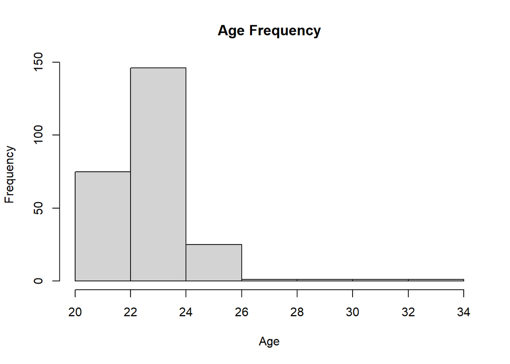

```r
hist(data$age,
     main="Age Frequency",
     xlab = "Age")
```

Age histogram skewed to the right.

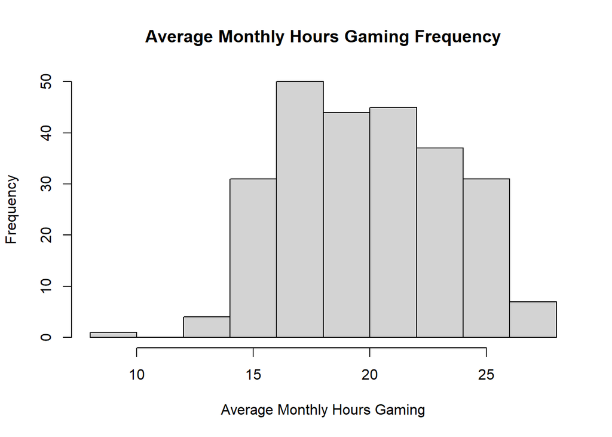

```r
hist(data$avg_monthly_hrs_gaming,
     main="Average Monthly Hours Gaming Frequency",
     xlab="Average Monthly Hours Gaming")
```

Average Monthly Hours Gaming histogram skewed to the left slightly.

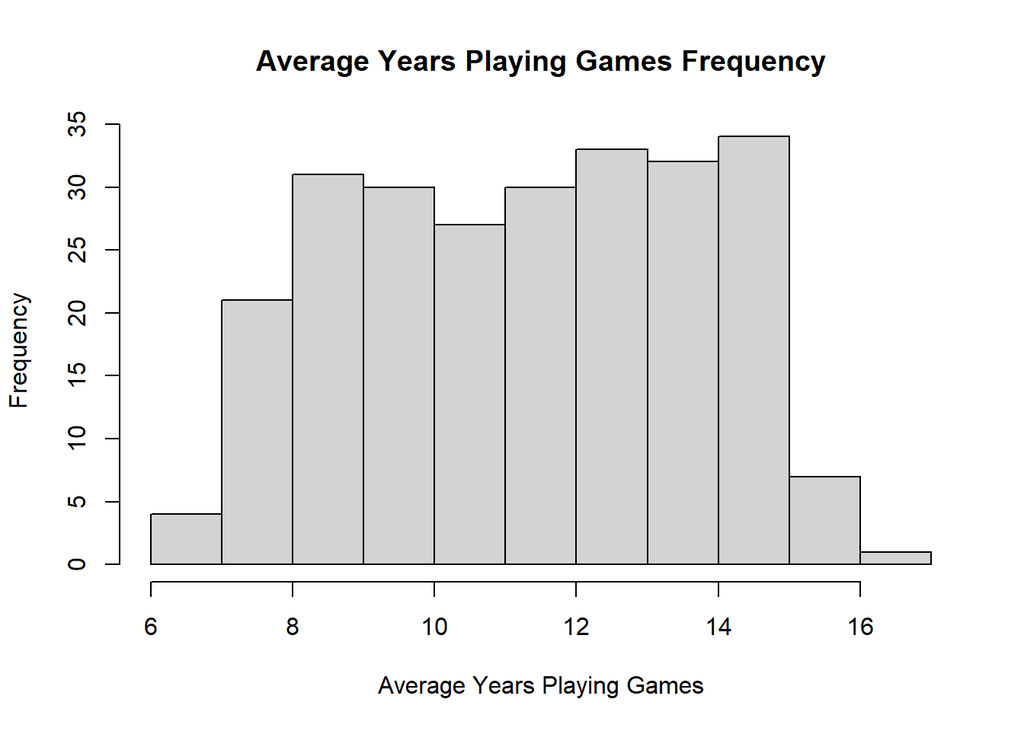

```r
hist(data$avg_years_playing_games,
     main="Average Years Playing Games Frequency",
     xlab = "Average Years Playing Games")
```

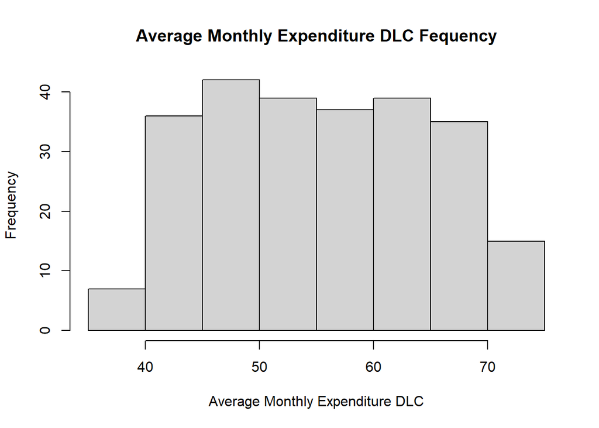

```r
hist(data$avg_monthly_expenditure_dlc,
     main="Average Monthly Expenditure DLC Fequency",
     xlab = "Average Monthly Expenditure DLC")
```

#### 2.2 Shapiro-Wilk’s Method (Significance test)

**null hypothesis:** the data are sampled from a Gaussian distribution.

If the P value is greater than 0.05 the answer is yes.

If the P value is less than or equal to 0.05 the answer is no.

```r
st_age <- shapiro.test(data$age)
if(st_age$p.value < 0.05) print("nope") else print("yep")
```

```
## [1] "nope"
```

```r
st_hours <- shapiro.test(data$avg_monthly_hrs_gaming)
if(st_hours$p.value < 0.05) print("nope") else print("yep")
```

```
## [1] "nope"
```

```r
st_years <- shapiro.test(data$avg_years_playing_games)
if(st_years$p.value < 0.05) print("nope") else print("yep")
```

```
## [1] "nope"
```

```r
st_bucks <- shapiro.test(data$avg_monthly_expenditure_dlc)
if(st_bucks$p.value < 0.05) print("nope") else print("yep")
```

```
## [1] "nope"
```

Null hypothesis rejected for all variables before sampling

#### 3. Linearity

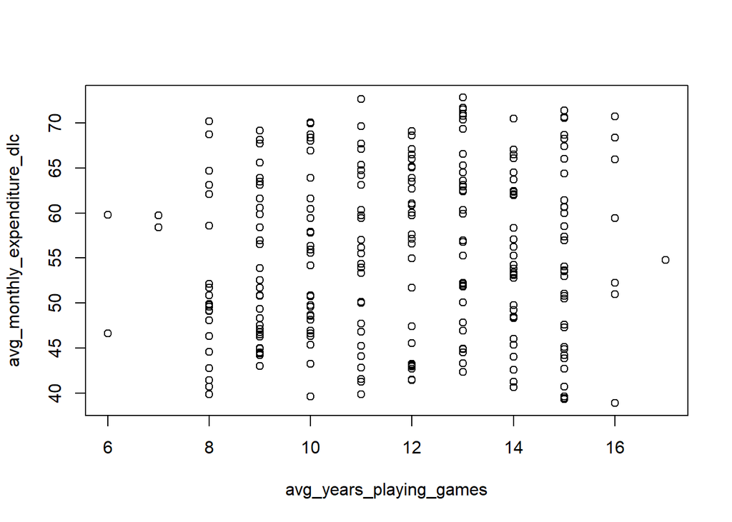

```r
plot(avg_monthly_expenditure_dlc ~ avg_years_playing_games, data)
```

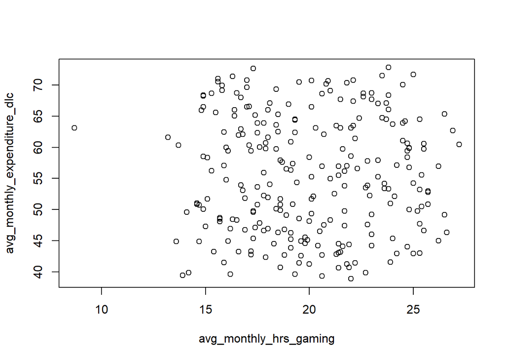

```r
plot(avg_monthly_expenditure_dlc ~ avg_monthly_hrs_gaming, data)
```

Weak relationship, and trying a linear fit would be reasonable.

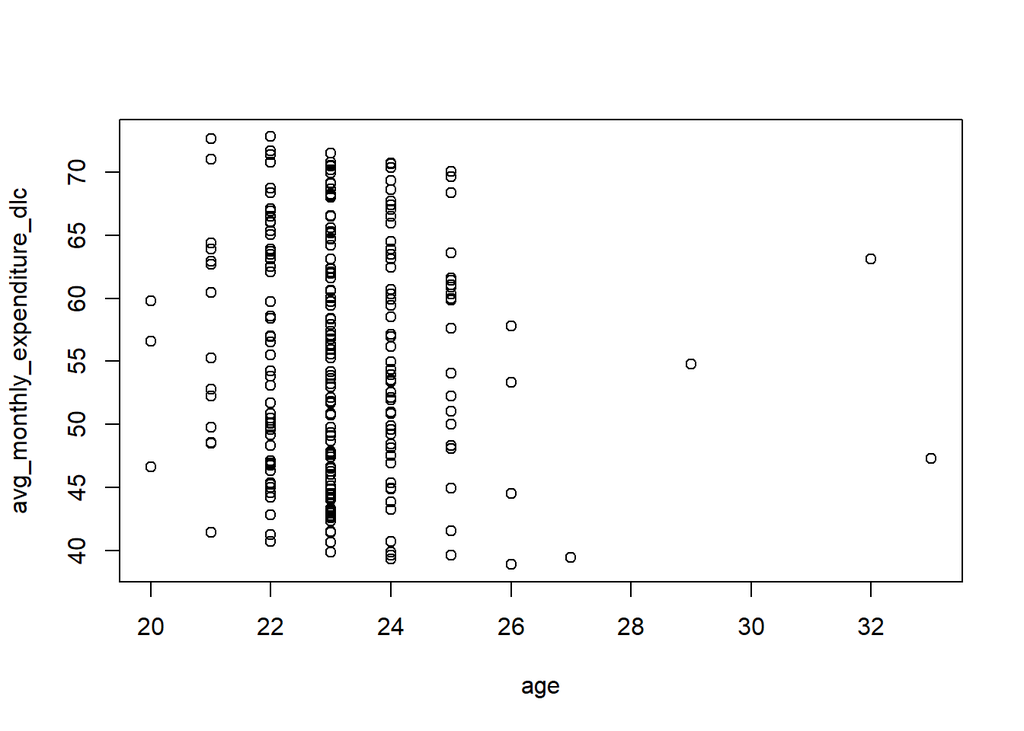

```r
plot(avg_monthly_expenditure_dlc ~ age, data)
```

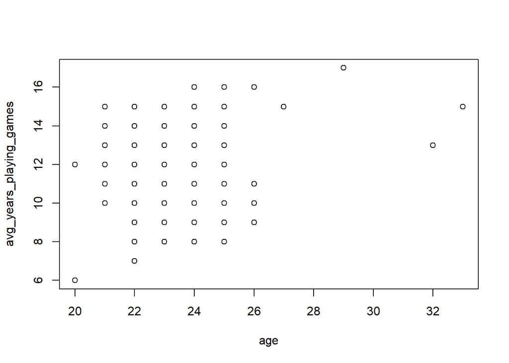

```r
plot(avg_years_playing_games ~ age, data)
```

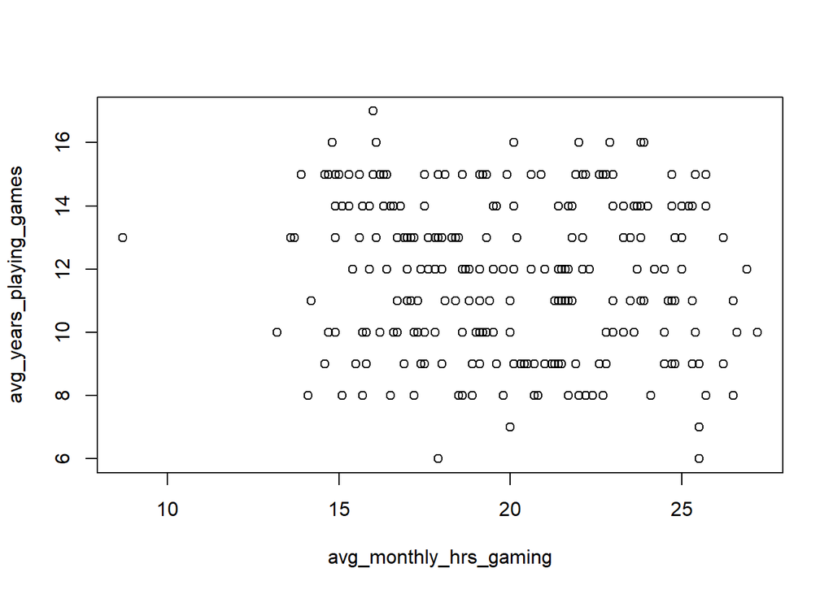

```r
plot(avg_years_playing_games ~ avg_monthly_hrs_gaming, data)
```

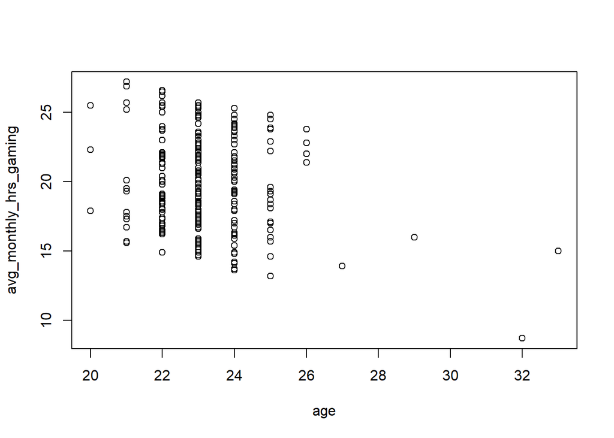

```r
plot(avg_monthly_hrs_gaming ~ age, data)
```

### Step 3. Linear Regression Analysis

After checking data meets assumptions, check the relationship between independent and dependent variables using linear regression.

```r
mod <- lm(avg_monthly_expenditure_dlc ~ avg_monthly_hrs_gaming,
          data = data)
summary(mod)
```

```
##
## Call:
## lm(formula = avg_monthly_expenditure_dlc ~ avg_monthly_hrs_gaming,
##     data = data)
##
## Residuals:
##      Min       1Q   Median       3Q      Max
## -16.5118  -7.9872  -0.1674   8.0363  17.3721
##
## Coefficients:
##                        Estimate Std. Error t value Pr(>|t|)
## (Intercept)            55.85640    3.44352  16.221   <2e-16 ***
## avg_monthly_hrs_gaming -0.01885    0.16978  -0.111    0.912
## ---
## Signif. codes:  0 '***' 0.001 '**' 0.01 '*' 0.05 '.' 0.1 ' ' 1
##
## Residual standard error: 9.311 on 248 degrees of freedom
## Multiple R-squared:  4.968e-05,  Adjusted R-squared:  -0.003982
## F-statistic: 0.01232 on 1 and 248 DF,  p-value: 0.9117
```

Not a Significant positive relationship between avg_monthly_hrs_gaming and avg_monthly_expenditure_dlc (p value > 0.05)

### Step 4. Check for homoscedasticity

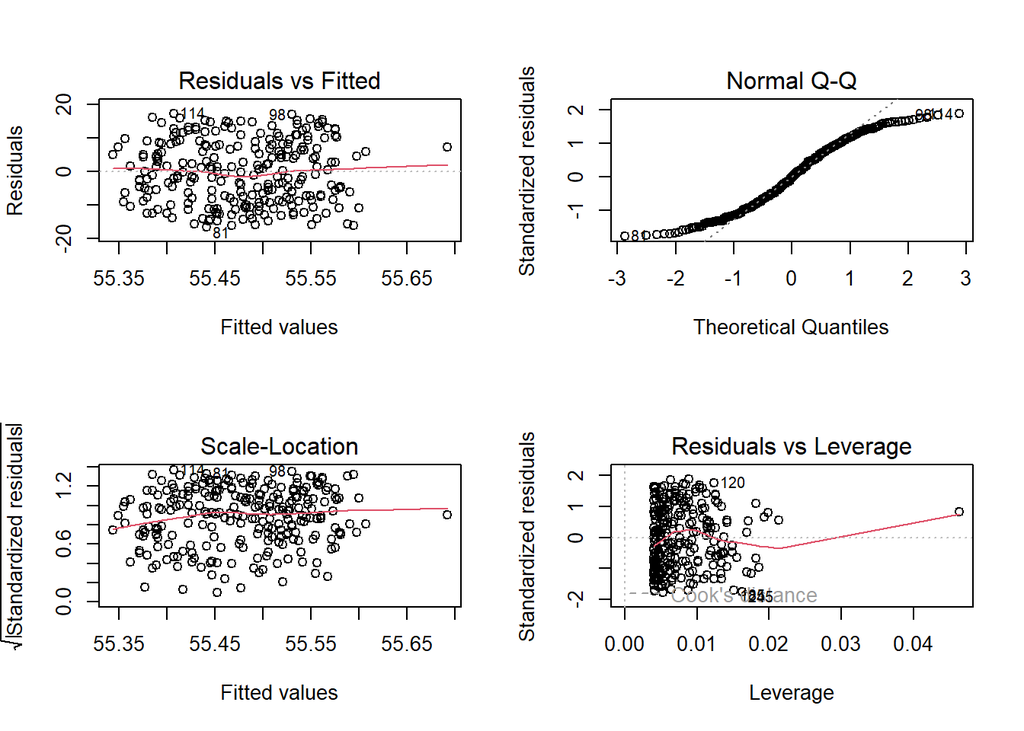

```r
par(mfrow=c(2,2))
plot(mod)
```

```r
par(mfrow=c(1,1))
```

Normal Q-Qplot doesn’t a perfect one-to-one line with the theoretical residuals.

### Step 5. Visualize the results with a graph

1. plot data points on graph

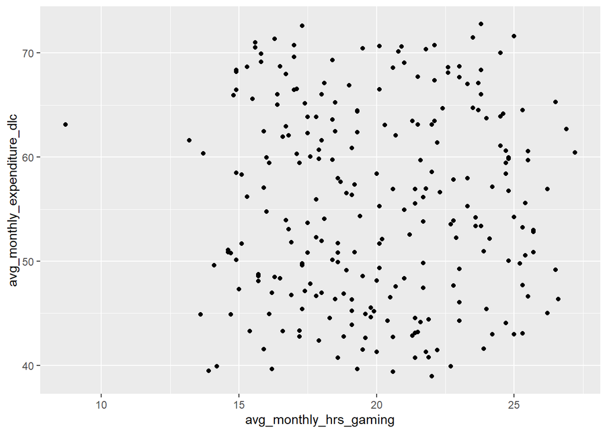

```r
graph <- ggplot(data, aes(x=avg_monthly_hrs_gaming,
                          y=avg_monthly_expenditure_dlc)) +
  geom_point()
graph
```

2. add linear regression line

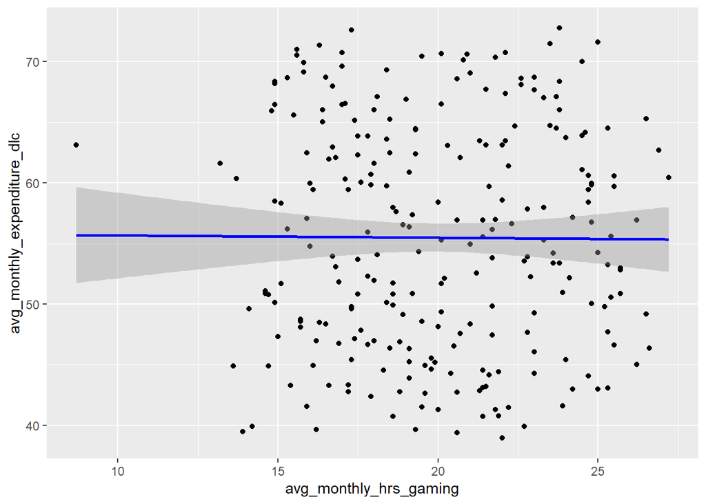

```r
graph <- graph + geom_smooth(method="lm", col="blue")
graph
```

3. add equation to regression line

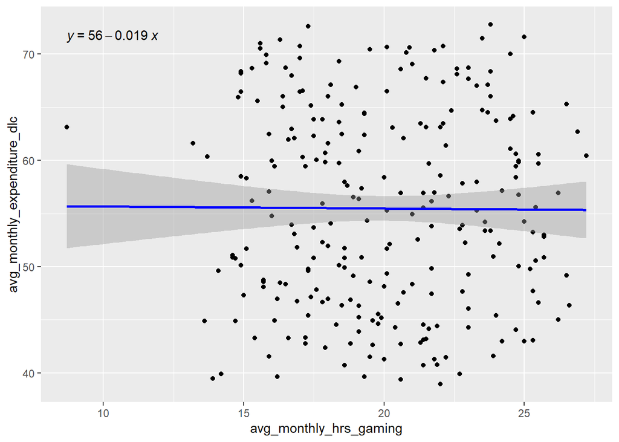

```r
graph <- graph +
  ggpubr::stat_regline_equation()
graph
```

4. make graph ready to publish

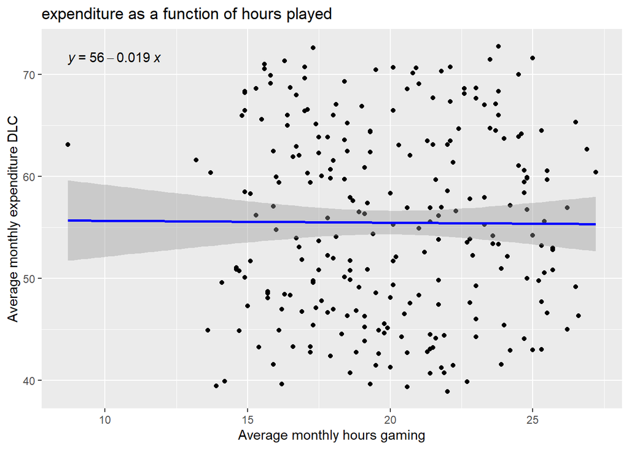

```r
graph <- graph + labs(title = "expenditure as a function of hours played",
                      x = "Average monthly hours gaming",
                      y = "Average monthly expenditure DLC")
graph
```

### Step 6. Results

The scatterplots showed that avg_monthly_hrs_gaming and avg_monthly_expenditure_dlc were the only variables that a linear fit would suit the data.

There is no significant relationship between avg_monthly_hrs_gaming and avg_monthly_expenditure_dlc.

# Sample Data

```r
set.seed(1234) # reproduce random values

sample_data <- sample_n(data, 200) # tibble 200 x 11

# lm() -
# dependent var. ~ independent var.
mod <- lm(avg_monthly_expenditure_dlc ~ avg_monthly_hrs_gaming,
          data = sample_data)
summary(mod)
```

```
##
## Call:
## lm(formula = avg_monthly_expenditure_dlc ~ avg_monthly_hrs_gaming,
##     data = sample_data)
##
## Residuals:
##      Min       1Q   Median       3Q      Max
## -16.2939  -8.2364   0.2041   7.8369  17.2410
##
## Coefficients:
##                        Estimate Std. Error t value Pr(>|t|)
## (Intercept)            56.61685    3.83003   14.78   <2e-16 ***
## avg_monthly_hrs_gaming -0.04529    0.18899   -0.24    0.811
## ---
## Signif. codes:  0 '***' 0.001 '**' 0.01 '*' 0.05 '.' 0.1 ' ' 1
##
## Residual standard error: 9.321 on 198 degrees of freedom
## Multiple R-squared:  0.00029,    Adjusted R-squared:  -0.004759
## F-statistic: 0.05743 on 1 and 198 DF,  p-value: 0.8109
```

```r
#attributes(mod)
#mod$residuals
# hist(mod$residuals)

plot <- ggplot(data = mod, mapping = aes(x = avg_monthly_hrs_gaming,
                                 y = avg_monthly_expenditure_dlc)) +
  # geom_point(alpha = 0.1, color = "blue") # add colours for points
  geom_point() + # plot dataset in a scatter plot
  labs(title = "Relationship between games monthly hours played + DLC expenditure",
       x = "Average Monthly Hours Gaming",
       y = "Average Monthly Expenditure DLC")

# plot + geom_smooth(method = lm, se = FALSE, formula=y~x) # probably this one
# plot + stat_smooth(method = lm, formula = y ~ x, geom = "smooth") # ok
# plot + geom_smooth(method = "loess", se = FALSE, formula=y~x) # curved line

coeff <- coefficients(mod)
coeff
```

```
##            (Intercept) avg_monthly_hrs_gaming
##            56.61684676            -0.04528886
```

```r
intercept <- coeff[1]
slope <- coeff[2]
slope
```

```
## avg_monthly_hrs_gaming
##            -0.04528886
```

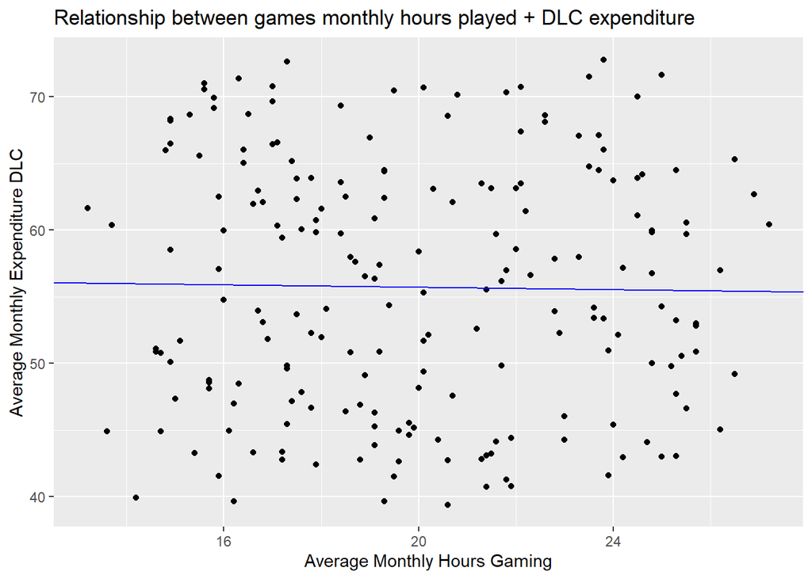

```r
plot +
  geom_abline(intercept = intercept, slope = slope, color="blue") # regression line
```

```r
# + geom_abline(mapping = aes(x = avg_monthly_hrs_gaming, y = avg_monthly_expenditure_dlc), data = mod)
```

Variables have a negative trend. The relationship is not perfectly linear.

```r
cor(sample_data$avg_monthly_hrs_gaming, sample_data$avg_monthly_expenditure_dlc)
```

```
## [1] -0.01702819
```

Correlation is near zero, so there is no apparent relationship.

# Visually Check Normality QQ Plots

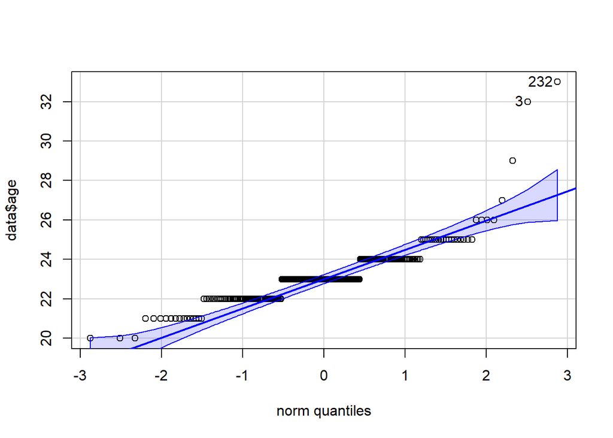

```
## [1] 232   3
```

```r
car::qqPlot(data$age)
```

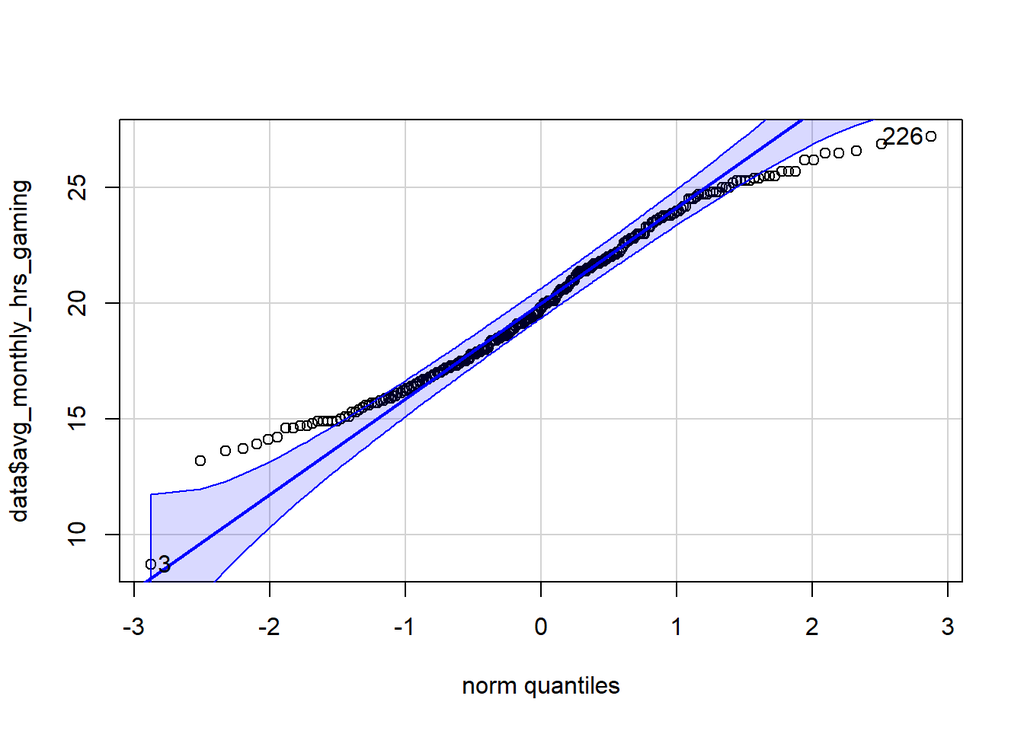

```
## [1]   3 226
```

```r
car::qqPlot(data$avg_monthly_hrs_gaming)
```

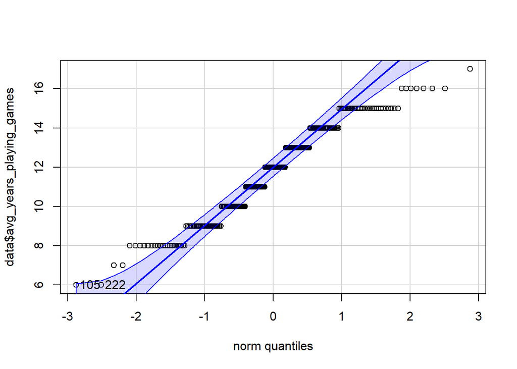

```
## [1] 105 222
```

```r
car::qqPlot(data$avg_years_playing_games)
```

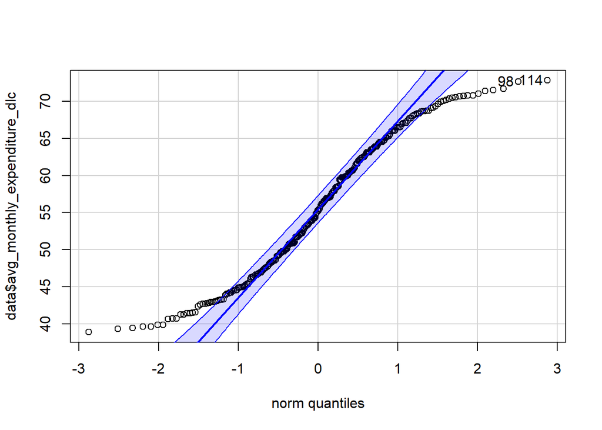

```
## [1] 114  98
```

```r
car::qqPlot(data$avg_monthly_expenditure_dlc)
```

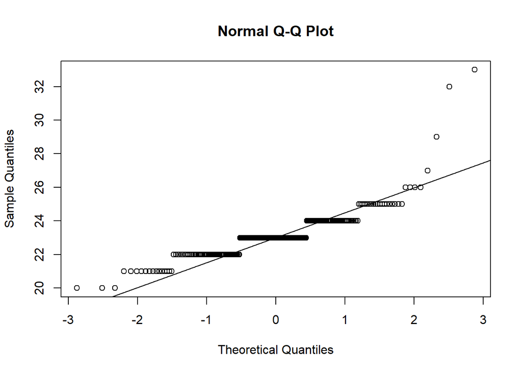

```r
qqnorm(data$age)
qqline(data$age)
```

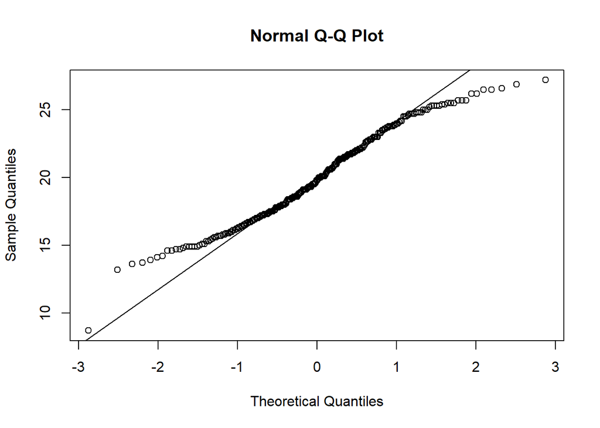

```r
qqnorm(data$avg_monthly_hrs_gaming)
qqline(data$avg_monthly_hrs_gaming)
```

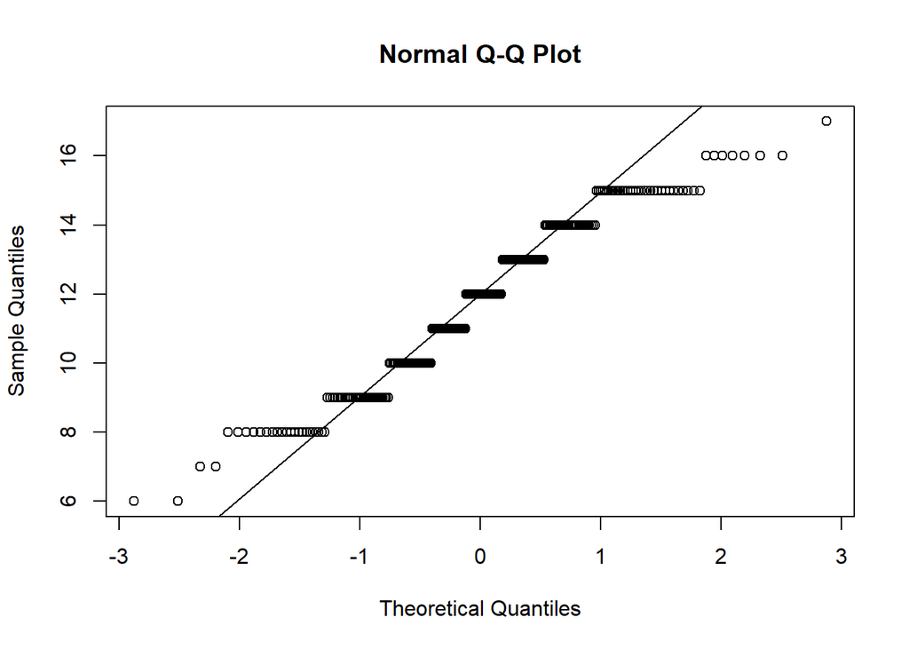

```r
qqnorm(data$avg_years_playing_games)
qqline(data$avg_years_playing_games)
```

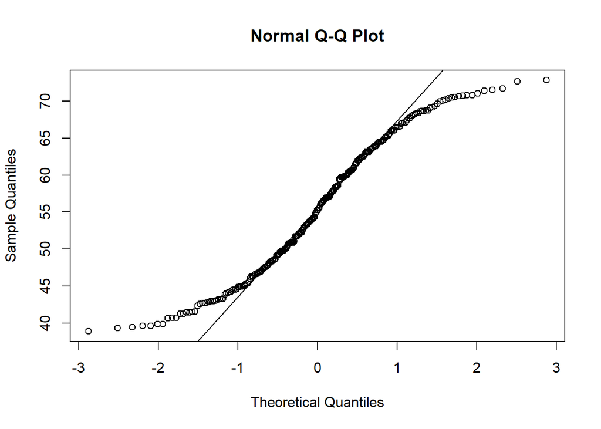

```r
qqnorm(data$avg_monthly_expenditure_dlc)
qqline(data$avg_monthly_expenditure_dlc)
```

# Age - transformations

```r
significance <- 0.05

par(mfrow=c(1,2)) # define plotting region
shapiro.test(data$age)
```

```
##
##  Shapiro-Wilk normality test
##
## data:  data$age
## W = 0.80693, p-value < 2.2e-16
```

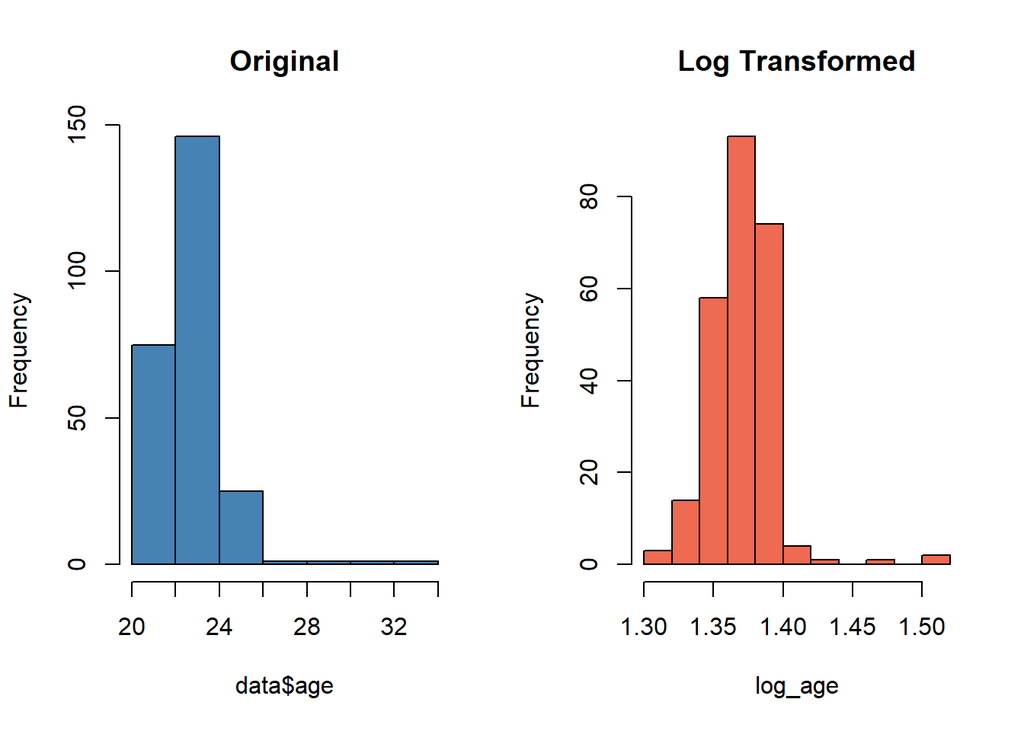

```r
# log transformation
log_age <- log10(data$age)
# histogram original distribution
hist(data$age, col='steelblue', main='Original')
# histogram log-transformed distribution
hist(log_age, col='coral2', main='Log Transformed')
```

```r
shapiro.test(log_age)
```

```
##
##  Shapiro-Wilk normality test
##
## data:  log_age
## W = 0.85511, p-value = 1.423e-14
```

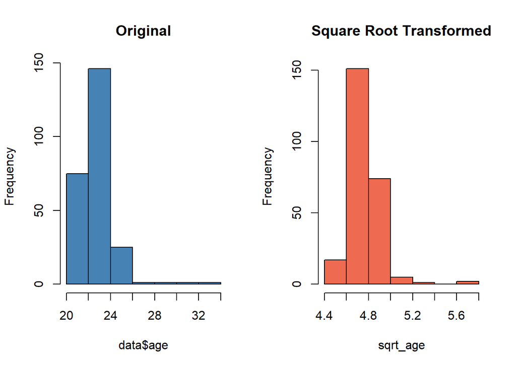

```r
# square root transformation
sqrt_age <- sqrt(data$age)
# histogram original distribution
hist(data$age, col='steelblue', main='Original')
# histogram square root-transformed distribution
hist(sqrt_age, col='coral2', main='Square Root Transformed')
```

```r
shapiro.test(sqrt_age)
```

```
##
##  Shapiro-Wilk normality test
##
## data:  sqrt_age
## W = 0.83284, p-value = 1.03e-15
```

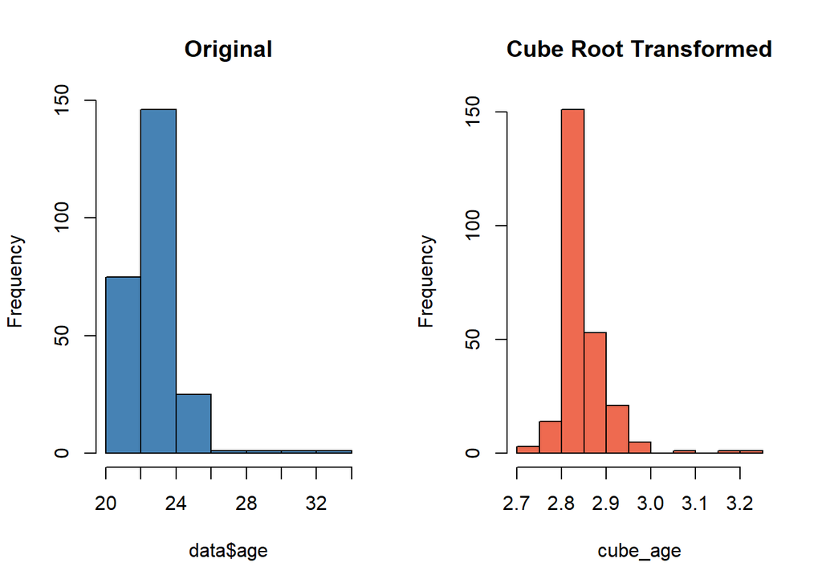

```r
# cube root transformation
cube_age <- data$age^(1/3)
# histogram original distribution
hist(data$age, col='steelblue', main='Original')
# histogram cube root-transformed
hist(cube_age, col='coral2', main='Cube Root Transformed')
```

```r
shapiro.test(cube_age)
```

```
##
##  Shapiro-Wilk normality test
##
## data:  cube_age
## W = 0.84067, p-value = 2.516e-15
```

```r
cube_age_p_value <- shapiro.test(cube_age)$p.value
if (cube_age_p_value < significance) {
  print(paste("Cube Root Transform of Age is less than ", significance))
} else {
  print(paste("Cube Root Transform of Age is less than ", significance))
}
```

```
## [1] "Cube Root Transform of Age is less than  0.05"
```

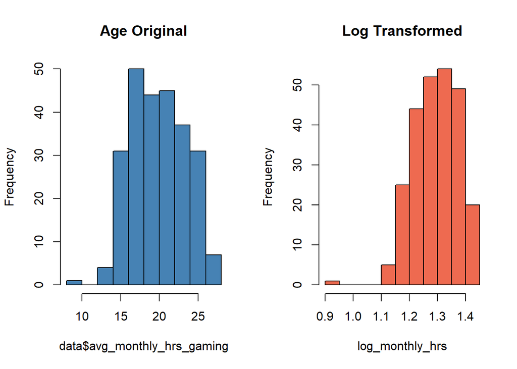

```r
significance <- 0.05

par(mfrow=c(1,2)) # define plotting region

log_monthly_hrs <- log10(data$avg_monthly_hrs_gaming)
hist(data$avg_monthly_hrs_gaming, col='steelblue', main='Age Original')
hist(log_monthly_hrs, col='coral2', main='Log Transformed')
```

```r
shapiro.test(log_monthly_hrs)
```

```
##
##  Shapiro-Wilk normality test
##
## data:  log_monthly_hrs
## W = 0.96709, p-value = 1.616e-05
```

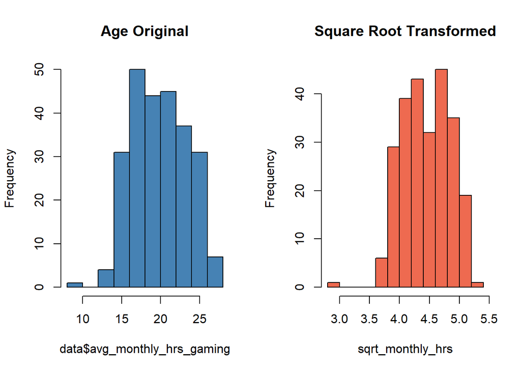

```r
sqrt_monthly_hrs <- sqrt(data$avg_monthly_hrs_gaming)
hist(data$avg_monthly_hrs_gaming, col='steelblue', main='Age Original')
hist(sqrt_monthly_hrs, col='coral2', main='Square Root Transformed')
```

```r
shapiro.test(sqrt_monthly_hrs)
```

```
##
##  Shapiro-Wilk normality test
##
## data:  sqrt_monthly_hrs
## W = 0.97577, p-value = 0.0002864
```

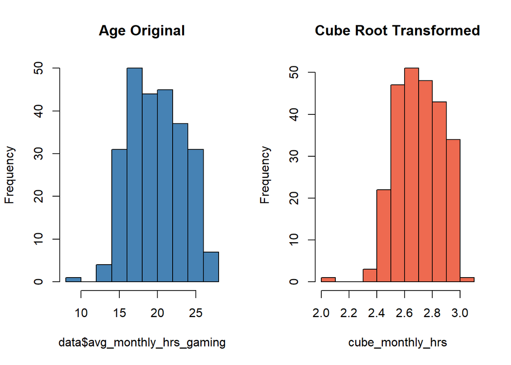

```r
cube_monthly_hrs <- data$avg_monthly_hrs_gaming^(1/3)
hist(data$avg_monthly_hrs_gaming, col='steelblue', main='Age Original')
hist(cube_monthly_hrs, col='coral2', main='Cube Root Transformed')
```

```r
shapiro.test(cube_monthly_hrs)
```

```
##
##  Shapiro-Wilk normality test
##
## data:  cube_monthly_hrs
## W = 0.9738, p-value = 0.0001439
```

```r
cube_monthly_hrs_p_value <- shapiro.test(cube_monthly_hrs)$p.value
if (cube_monthly_hrs_p_value < significance) {
  print(paste("Cube Root Transform of Avg. Monthly Hours Gaming is less than ", significance))
} else {
  print(paste("Cube Root Transform of Avg. Monthly Hours Gaming is less than ", significance))
}
```

```
## [1] "Cube Root Transform of Avg. Monthly Hours Gaming is less than  0.05"
```

# References

**OpenIntro Statistics:**

M., D., D., C. and Çetinkaya-Rundel, M., 2019. OpenIntro Statistics. OpenIntro, Incorporated.

OpenIntro Statistics. 2022. OpenIntro Statistics. [ONLINE] Available at: https://www.openintro.org/book/os/. [Accessed 18 January 2023].

**Linear Regression:**

Rebecca Bevans. 2023. Linear Regression in R | A Step-by-Step Guide & Examples. [ONLINE] Available at: https://www.scribbr.com/statistics/linear-regression-in-r/. [Accessed 18 January 2023].